# TidyverseRecap

Anna Lisa und Wenjia

2023-11-13

```r
#einlesen und ersten Einträge anschauen
head(gapminder_raw)
```

```
##       country year      pop continent lifeExp gdpPercap
## 1 Afghanistan 1952  8425333      Asia  28.801  779.4453
## 2 Afghanistan 1957  9240934      Asia  30.332  820.8530
## 3 Afghanistan 1962 10267083      Asia  31.997  853.1007
## 4 Afghanistan 1967 11537966      Asia  34.020  836.1971
## 5 Afghanistan 1972 13079460      Asia  36.088  739.9811
## 6 Afghanistan 1977 14880372      Asia  38.438  786.1134
```

## 6.1 Data Wrangling

## Filter the data for the Americas in 2007, deselect all other variables.

```r
library(tidyverse)
#dim(gapminder_raw)
gapminder1 <- gapminder_raw %>%
  filter(continent == "Americas", year == "2007")%>%
  select(country, lifeExp)
head(gapminder1)
```

```
##     country lifeExp
## 1 Argentina  75.320
## 2   Bolivia  65.554
## 3    Brazil  72.390
## 4    Canada  80.653
## 5     Chile  78.553
## 6  Colombia  72.889
```

## Create the variable gdp, defined as the product of population size and gdp per person

```r
gapminder_raw <- gapminder_raw %>%
  mutate(gdp = gdpPercap * pop)
head(gapminder_raw)
```

```
##       country year      pop continent lifeExp gdpPercap         gdp
## 1 Afghanistan 1952  8425333      Asia  28.801  779.4453  6567086330
## 2 Afghanistan 1957  9240934      Asia  30.332  820.8530  7585448670
## 3 Afghanistan 1962 10267083      Asia  31.997  853.1007  8758855797
## 4 Afghanistan 1967 11537966      Asia  34.020  836.1971  9648014150
## 5 Afghanistan 1972 13079460      Asia  36.088  739.9811  9678553274
## 6 Afghanistan 1977 14880372      Asia  38.438  786.1134 11697659231
```

## Identify the observation with lowest gdp per person.

```r
lowest_gdp<- gapminder_raw %>% filter(gdpPercap==min(gdpPercap))
lowest_gdp
```

```
##           country year      pop continent lifeExp gdpPercap         gdp
## 1 Congo Dem. Rep. 2002 55379852    Africa  44.966  241.1659 13355730548
```

## Identify all observations with above average life expectancy, stratified for each continent.

```r
avg_life_exp<- gapminder_raw %>% group_by(continent) %>% summarize(avg_life_exp = mean(lifeExp))
data_con_average <- gapminder_raw %>% left_join(avg_life_exp, by = "continent")
above_average<- data_con_average%>% filter(lifeExp> avg_life_exp)
head(above_average)
```

```
##   country year      pop continent lifeExp gdpPercap         gdp avg_life_exp
## 1 Albania 1987  3075321    Europe  72.000  3738.933 11498418358     71.90369
## 2 Albania 1997  3428038    Europe  72.950  3193.055 10945912519     71.90369
## 3 Albania 2002  3508512    Europe  75.651  4604.212 16153932130     71.90369
## 4 Albania 2007  3600523    Europe  76.423  5937.030 21376411360     71.90369
## 5 Algeria 1967 12760499    Africa  51.407  3246.992 41433235247     48.86533
## 6 Algeria 1972 14760787    Africa  54.518  4182.664 61739408943     48.86533
```

## Count the observations identified in the last step.

```r
observations <- nrow(above_average) # nrow generell ganz hilfreich
observations
```

```
## [1] 873
```

## Compute the mean life expectancy (the grand mean; ie., across all observations)

```r
across_mean <- mean(gapminder_raw$lifeExp)
across_mean
```

```
## [1] 59.47444
```

## Compute the mean life expectancy for each year

```r
mean_years <- gapminder_raw %>% group_by(year) %>% summarise(mean_years=mean(lifeExp))
mean_years
```

```
## # A tibble: 12 × 2
##     year mean_years
##    <int>      <dbl>
##  1  1952       49.1
##  2  1957       51.5
##  3  1962       53.6
##  4  1967       55.7
##  5  1972       57.6
##  6  1977       59.6
##  7  1982       61.5
##  8  1987       63.2
##  9  1992       64.2
## 10  1997       65.0
## 11  2002       65.7
## 12  2007       67.0
```

## 6.2 Data Visualization

## Create a scatter plot showing the association of gdp per person and life expectancy. Put the putative cause on the X axis and the putative effect on the y axis.

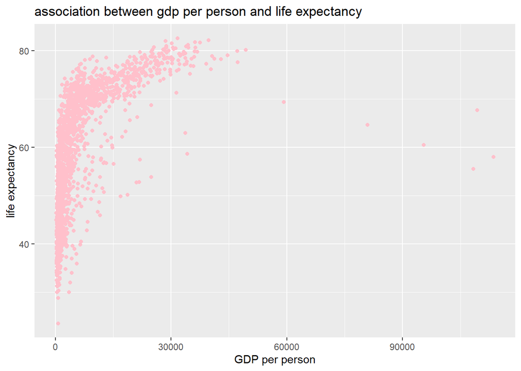

```r
library(ggplot2)
ggplot(gapminder_raw, aes(x= gdpPercap, y=lifeExp)) + geom_point(color="pink") + labs(x= "GDP per person", y="life expectancy") + ggtitle("association between gdp per person and life expectancy")
```

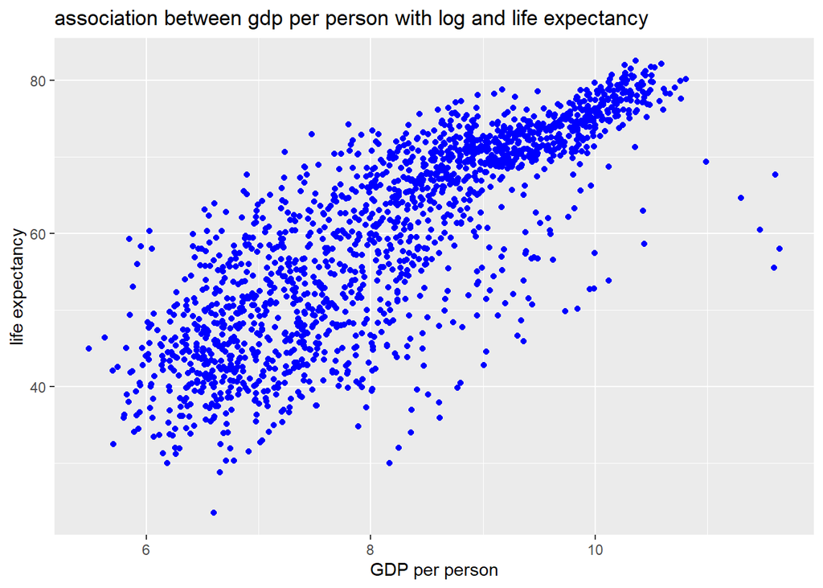

```r
#in this case we could use log(GDP per person) instead of GDP per person
ggplot(gapminder_raw, aes(x= log(gdpPercap+1), y=lifeExp)) + geom_point(color="blue") + labs(x= "GDP per person", y="life expectancy") + ggtitle("association between gdp per person with log and life expectancy")
```

## Add a rolling average line (also known as LOESS smoother).

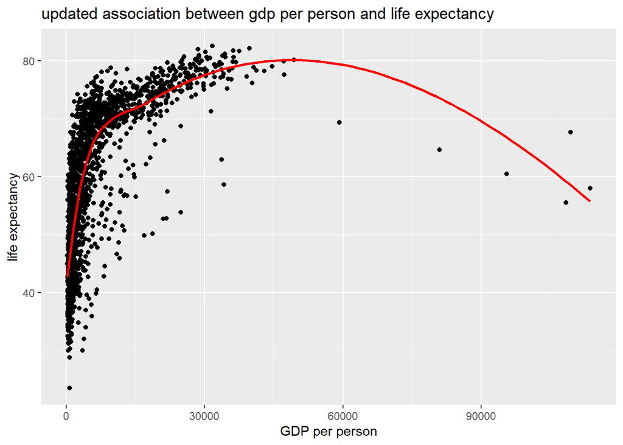

```r
ggplot(gapminder_raw, aes(x= gdpPercap, y=lifeExp)) + geom_point() + geom_smooth(method= "loess", se=FALSE, color="red") + labs(x= "GDP per person", y="life expectancy") + ggtitle("updated association between gdp per person and life expectancy")
```

3. Add a linear model line

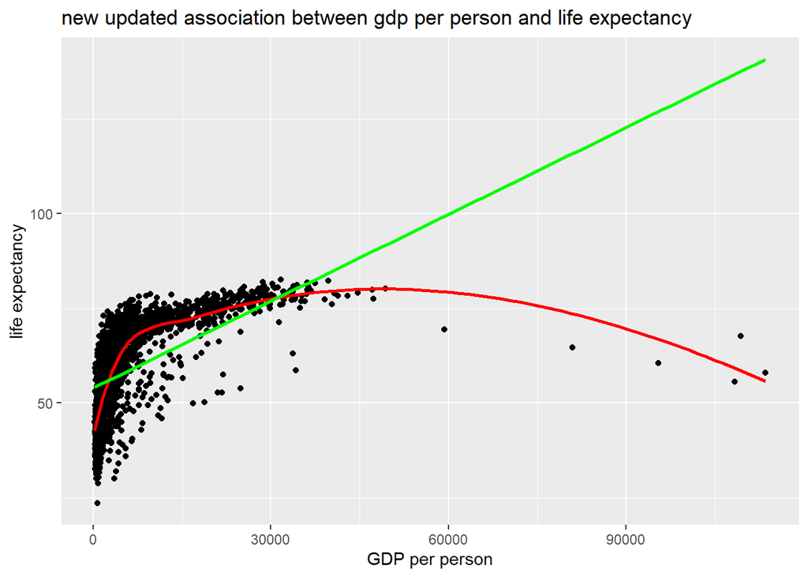

```r
ggplot(gapminder_raw, aes(x= gdpPercap, y=lifeExp)) + geom_point() + geom_smooth(method="loess", se=FALSE, color="red") + geom_smooth(method= "lm", se=FALSE, color="green") + labs(x= "GDP per person", y="life expectancy") + ggtitle("new updated association between gdp per person and life expectancy")
```

4. Create scatter plot

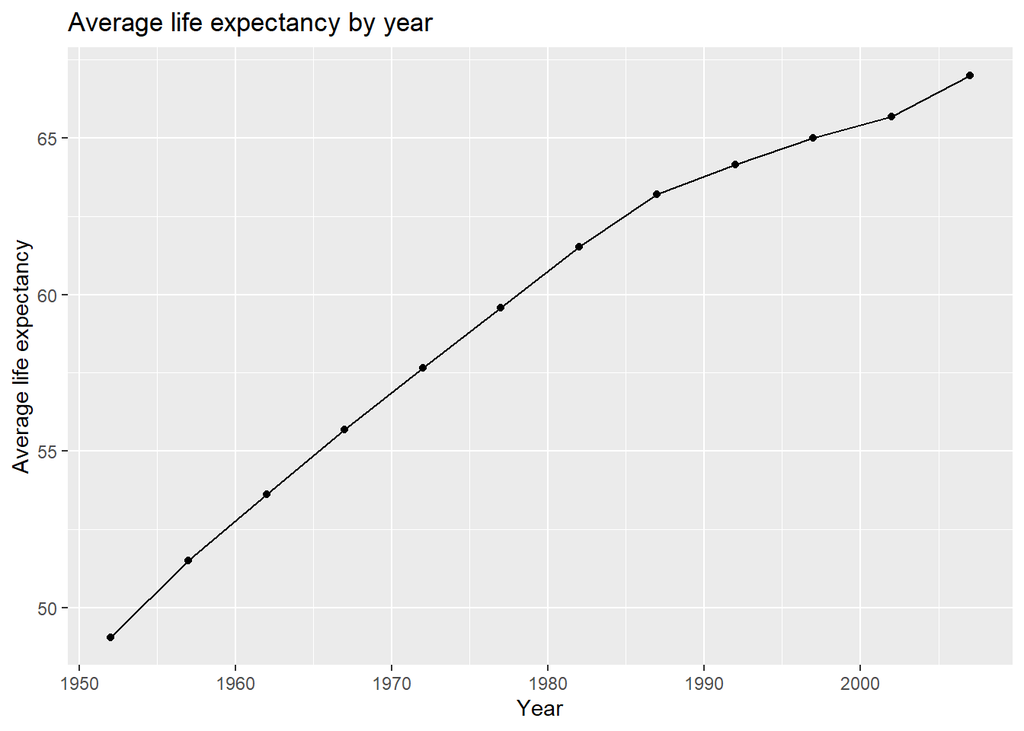

```r
ggplot(mean_years, aes(x=year, y=mean_years)) + geom_point()+geom_line()+labs(x="Year", y="Average life expectancy")+ ggtitle("Average life expectancy by year")
```

5. Modify the last plot so that there is a line for each continent

```r
mean_years_continent <- gapminder_raw %>% group_by(year, continent) %>% summarize(mean_years =mean(lifeExp))
```

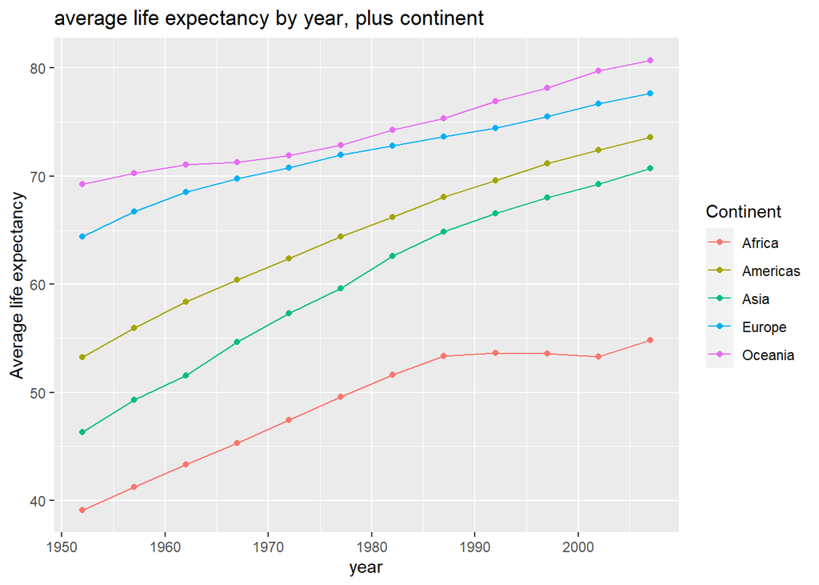

```r
ggplot(mean_years_continent, aes(x=year, y=mean_years, color=continent, group=continent))+ geom_point() + geom_line() +labs(x="year", y="Average life expectancy", color="Continent")+ ggtitle("average life expectancy by year, plus continent ")
```

```r
## group und continent für Projekt merken
```

6. Create a scatter plot showing the association of gdp per person and life expectancy

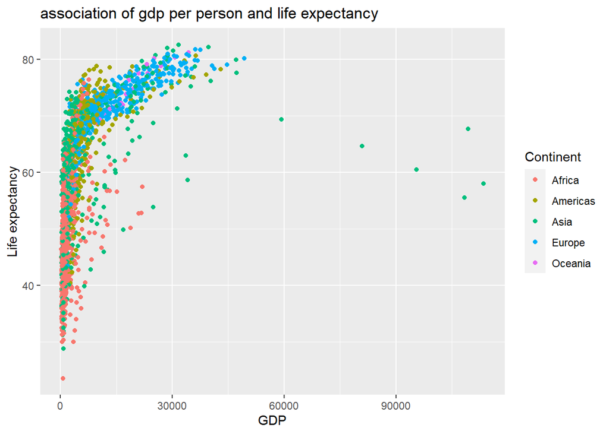

```r
ggplot(gapminder_raw, aes(x=gdpPercap, y=lifeExp, color=continent)) + geom_point() + labs(x= "GDP", y="Life expectancy", color="Continent") + ggtitle("association of gdp per person and life expectancy")
```

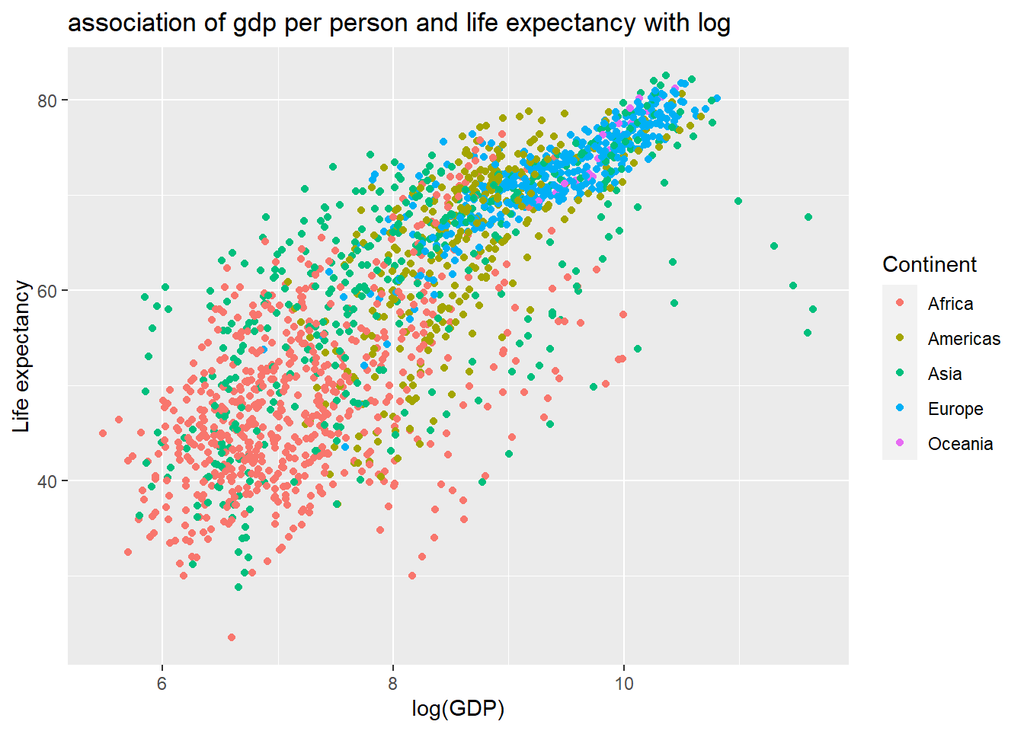

```r
ggplot(gapminder_raw, aes(x=log(gdpPercap), y=lifeExp, color=continent)) + geom_point() + labs(x= "log(GDP)", y="Life expectancy", color="Continent") + ggtitle("association of gdp per person and life expectancy with log")
```

7. Modify last plot so that the size of the dots represents the population size. in addition, increase the transparency of the dots in order to mitigate overplotting

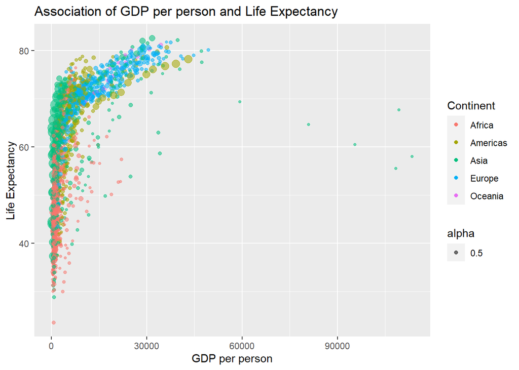

```r
ggplot(gapminder_raw, aes(x = gdpPercap, y = lifeExp, color = continent, size = pop, alpha = 0.5)) +
  geom_point() +
  labs(x = "GDP per person", y = "Life Expectancy", color = "Continent", size = "Population") +
  ggtitle("Association of GDP per person and Life Expectancy") +
  guides(size = "none")
```

8. Modify last plot so that there is a facet for each continent -> using facet wrap

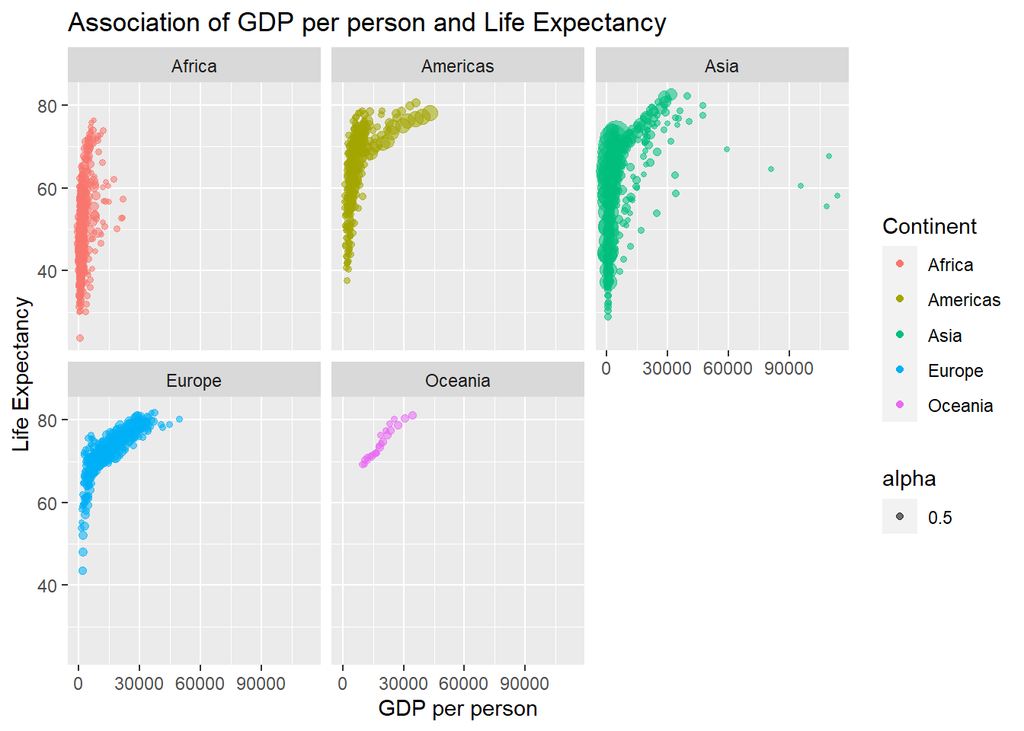

```r
ggplot(gapminder_raw, aes(x = gdpPercap, y = lifeExp, color = continent, size = pop, alpha = 0.5)) +
  geom_point() +
  labs(x = "GDP per person", y = "Life Expectancy", color = "Continent", size = "Population") +
  ggtitle("Association of GDP per person and Life Expectancy") +
  facet_wrap(~ continent, nrow = 2) +
  guides(size = "none")
```

9. Modify the last plot so that GDP is log transformed

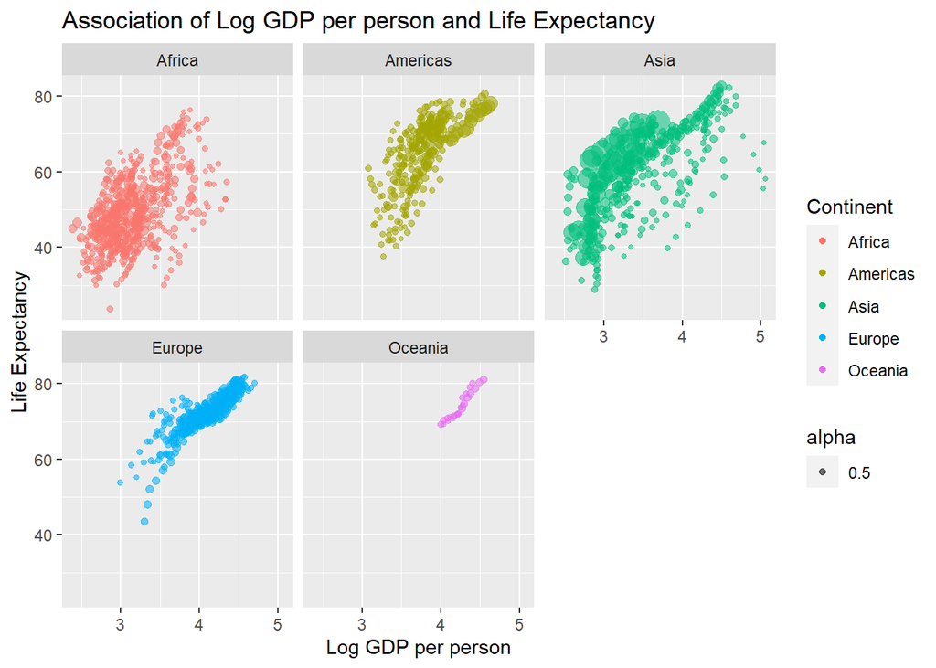

```r
ggplot(gapminder_raw, aes(x = log10(gdpPercap), y = lifeExp, color = continent, size = pop, alpha = 0.5)) +
  geom_point() +
  labs(x = "Log GDP per person", y = "Life Expectancy", color = "Continent", size = "Population") +
  ggtitle("Association of Log GDP per person and Life Expectancy") +
  facet_wrap(~ continent, nrow = 2) +
  guides(size = "none")
```

## Weitere Beispiele using Yeastract dataset

1. violin plot

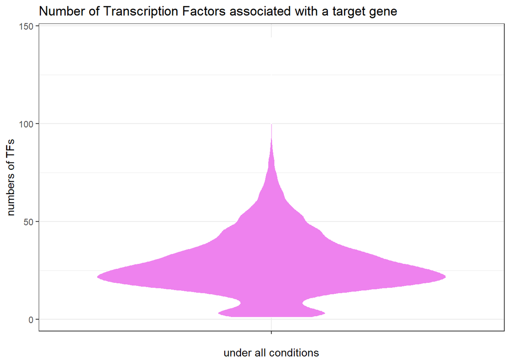

```r
new_names <- c( "Regulator systematic", "Regulator standard", "Target systematic", "Target standard", "Id", "Date", "Environment", "Regulation", "Type", "Method")
colnames(YEASTRACT) <- new_names

plot_dat <- YEASTRACT %>%
  group_by(`Target systematic`) %>%
  summarise(num_tf = n_distinct(`Regulator systematic`)) %>%
  ggplot(aes(x = "", y = num_tf)) +  # Leere x-Achse
  geom_violin(fill = "violet", color = "white") +
  ggtitle("Number of Transcription Factors associated with a target gene") +
  xlab("under all conditions") +
  ylab("numbers of TFs") +
  theme_bw()

plot_dat
```

2. combinition of violin plots, with better view of comparision

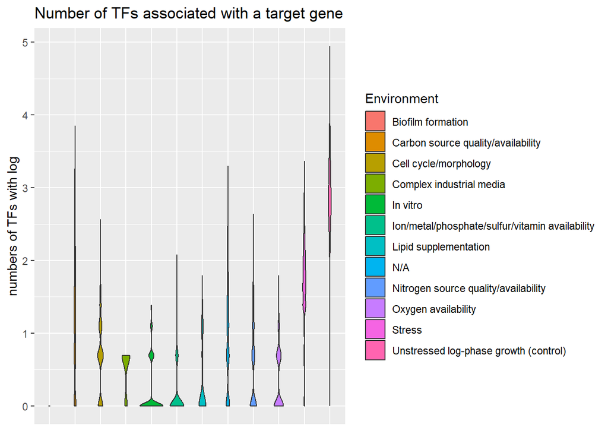

```r
counts <- data.frame()
for(item in unique(YEASTRACT$Environment)){
  control <- YEASTRACT %>%
    filter(Environment == item) %>%
    group_by(`Target systematic`) %>%
    summarise(num_tf = n_distinct(`Regulator systematic`)) %>%
    mutate(Environment = item)
  counts <- rbind(counts,control)
}
ggplot(counts, aes(x = Environment, y = log(num_tf), fill = Environment)) +
  geom_violin() +
  ggtitle("Number of TFs associated with a target gene ") +
  xlab("Environments") +
  ylab("numbers of TFs with log") +
  theme(axis.title.x=element_blank(),
        axis.text.x=element_blank(),
        axis.ticks.x=element_blank())
```

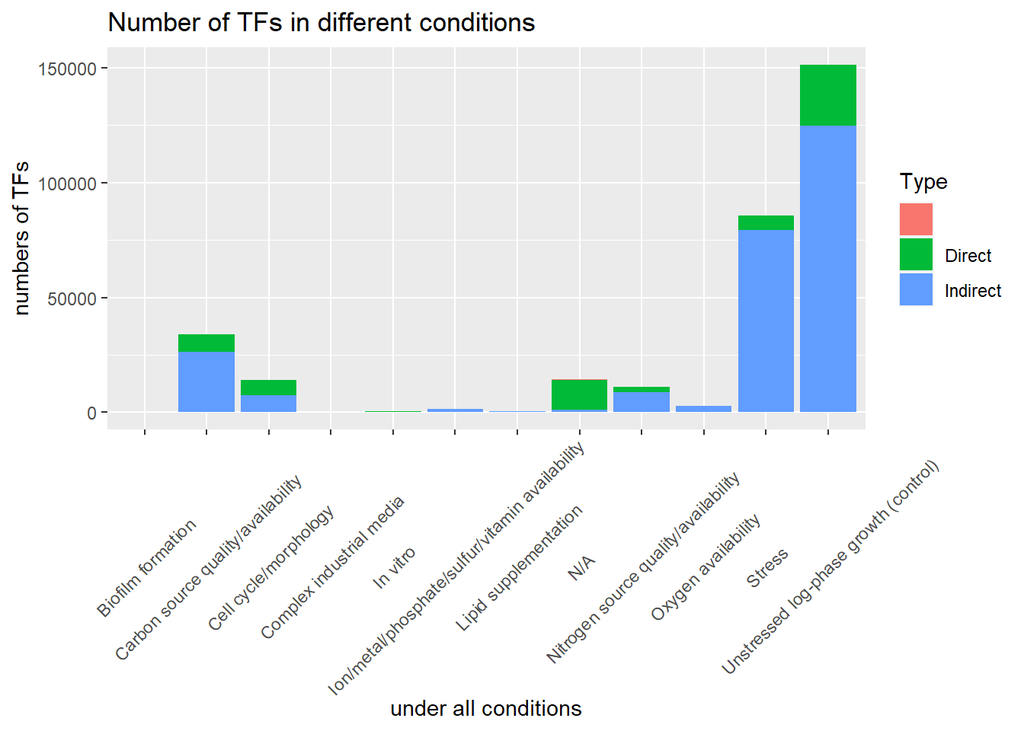

```r
YEASTRACT %>%
  group_by(`Environment`) %>%
  ggplot(aes(x = Environment, fill = Type)) +
  geom_bar() +
  ggtitle("Number of TFs in different conditions") +
  xlab("under all conditions") +
  ylab("numbers of TFs") +
  theme(axis.text.x = element_text(angle = 45, vjust = 0.5, hjust = 0.5))
```